# Chapter 2 Exercises

## Exercise 10

This exercise involved the **Boston** housing data set. a) To begin, load in the **Boston** data set. The **Boston** data set is part of the **MASS** library in **R**.

```r
library(MASS)
```

Now the data set is contained in the object **Boston**.

How many rows are in this data set? How many columns? What do the rows and columns represent?

```r
# ?Boston
```

Referring to the help file, this data set has 506 rows and 14 columns. Each row represents a suburb of Boston, and the columns are:

- **crim**: per capita crime rate by town
- **zn**: proportion of residential land zoned for lots over 25,000 sq.ft.
- **indus**: proportion of non-retail business acres per town
- **chas**: Charles River dummy variable (= 1 if tract bounds river; 0 otherwise).
- **nox**: nitrogen oxides concentration (parts per 10 million).
- **rm**: average number of rooms per dwelling.
- **age**: proportion of owner-occupied units built prior to 1940.
- **dis**: weighted mean of distances to five Boston employment centers.
- **rad**: index of accessibility to radial highways.
- **tax**:full-value property-tax rate per $10,000.
- **ptratio**: pupil-teacher ratio by town
- **black**: $1000(Bk - 0.63)^2$ where $Bk$ is the proportion of black people by town
- **lstat**: lower status of the population (percent)
- **medv**: median value of owner-occupied homes in $1000s
2. Make some pairwise scatterplots of the predictors (columns) in this data set. Describe your findings.

It would not be feasible to look at all of the scatterplots, as there are 91 of them in total. Instead, in this part, we’ll look at scatterplots for **nox** versus all of the other predictors, as we may be interested in predicting the concentration of potentially harmful gases.

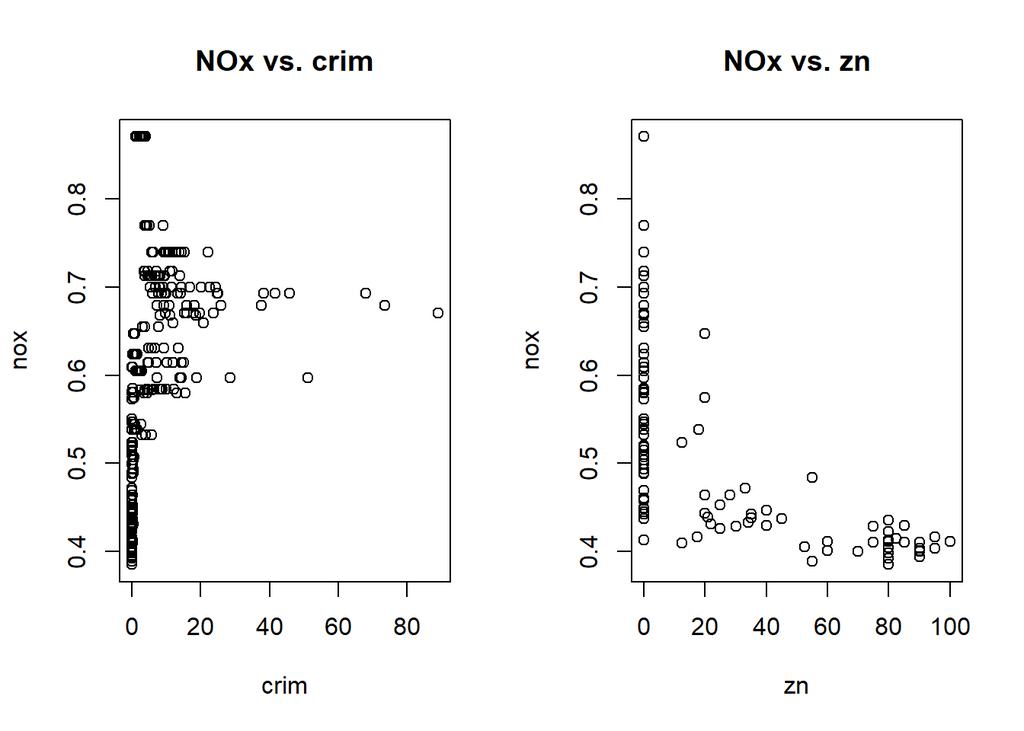

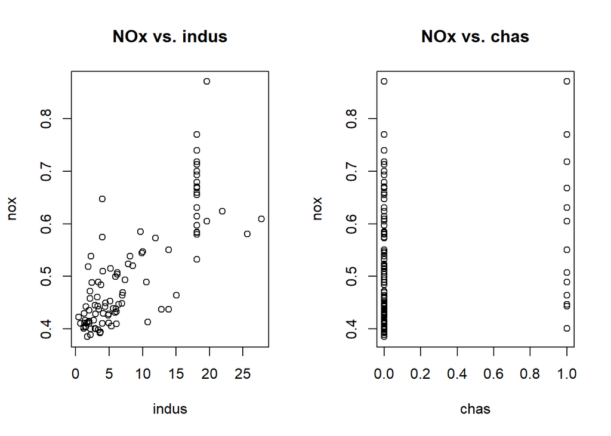

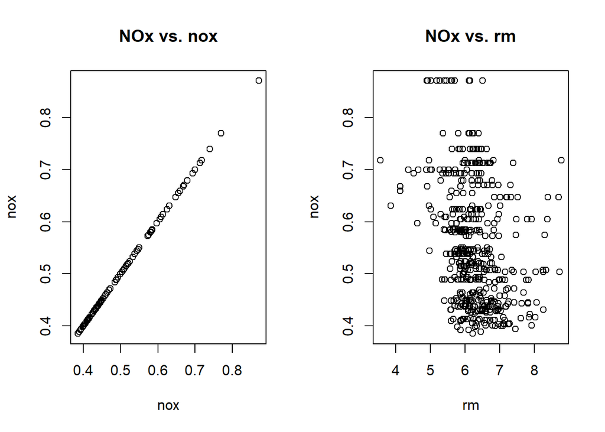

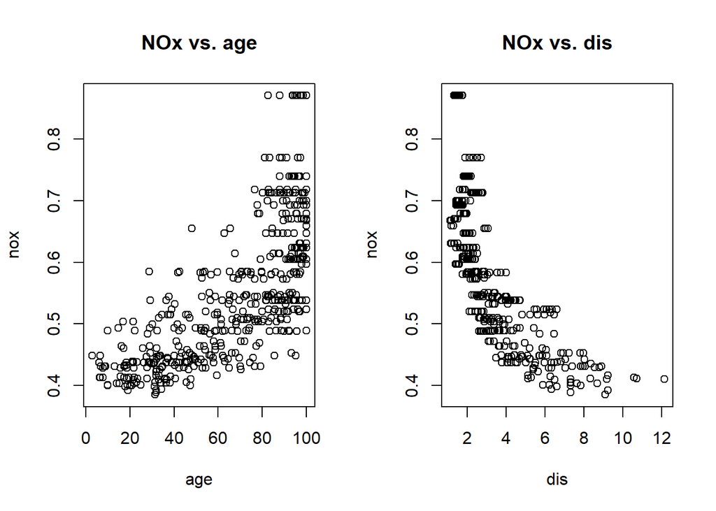

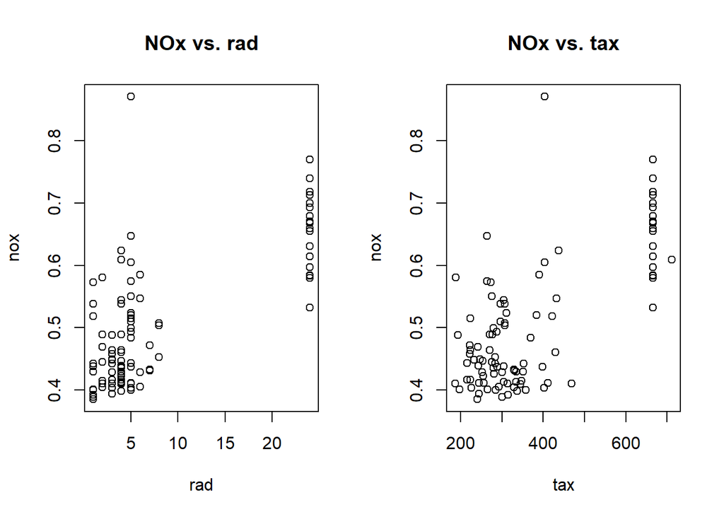

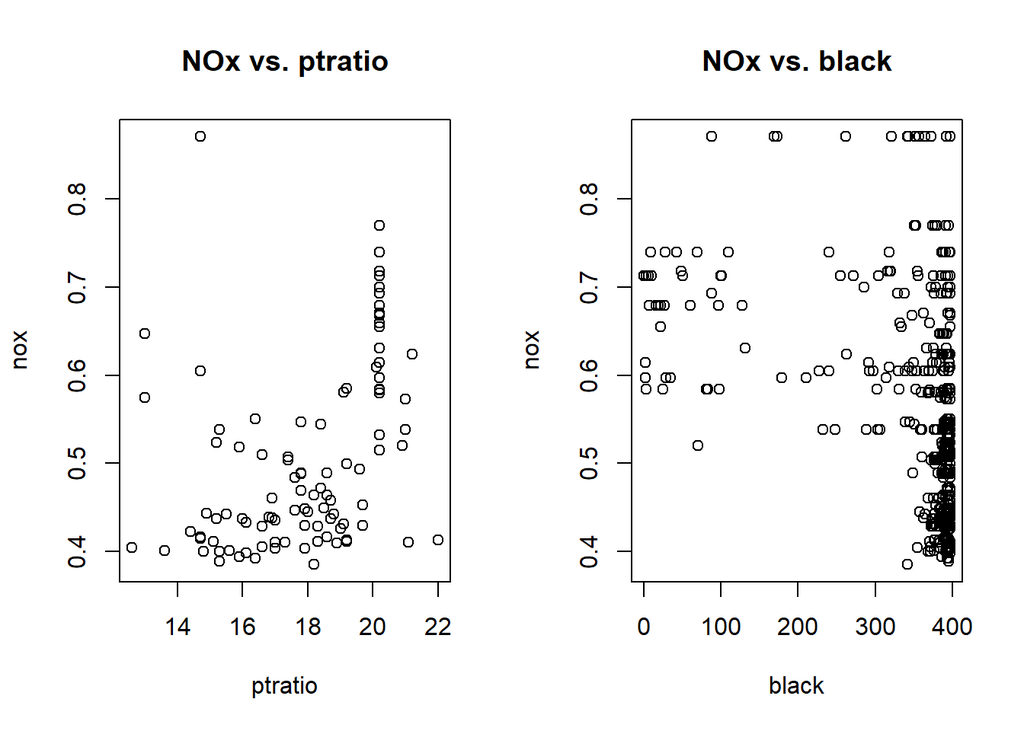

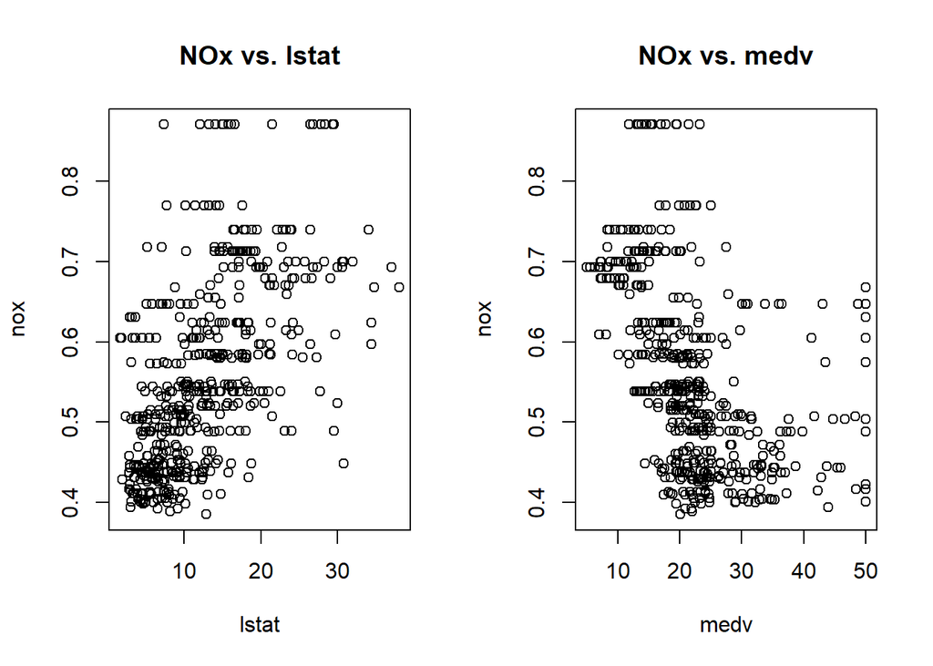

```r
par(mfrow=c(1,2))
for (i in 1:14){
  plot(Boston[,i], Boston$nox, xlab=names(Boston)[i], ylab="nox", main=paste("NOx vs.", names(Boston)[i]))
}
```

From these scatterplots, we can observe that **nox** has the strongest positive correlations with **indus**, **age**, **rad**, **tax**, **ptratio**, and **lstat**, and the strongest negative correlations with **medv**, **black**, **dis**, and **zn**.

3. Are there any predictors associated with per capita crime rate? If so, explain the relationship.

Crime is another potentially harmful thing we would wish to predict, so we should look at the scatterplots of crime vs. the other predictors.

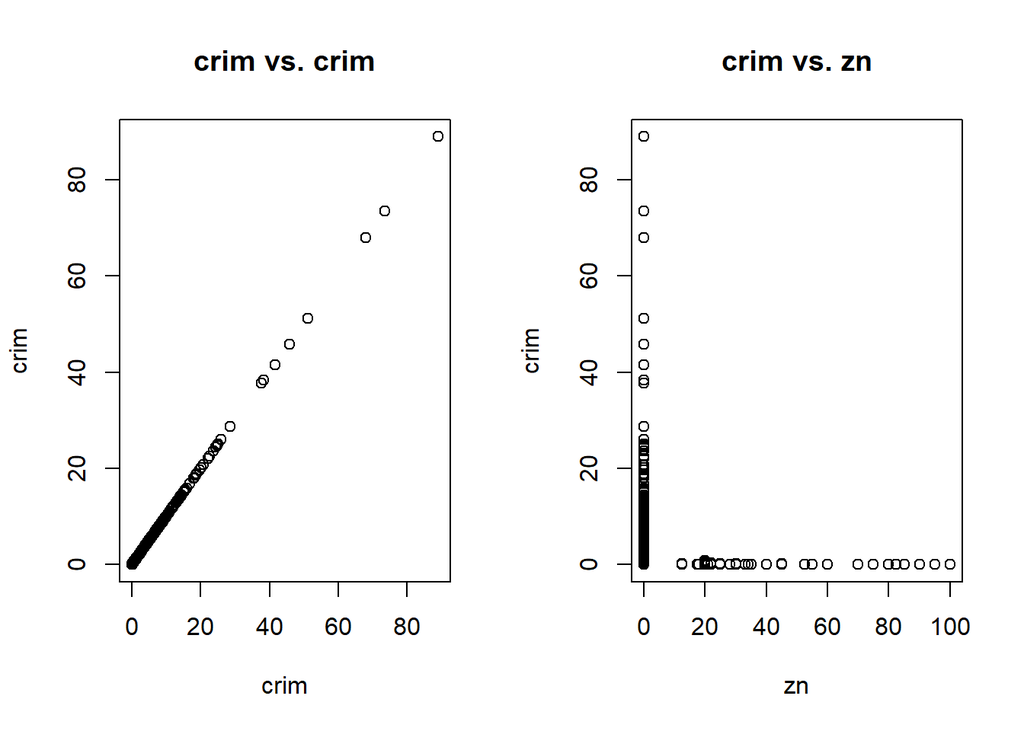

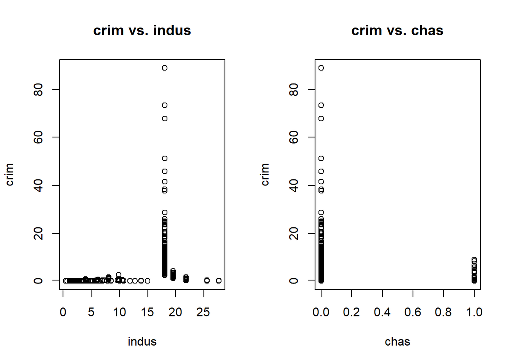

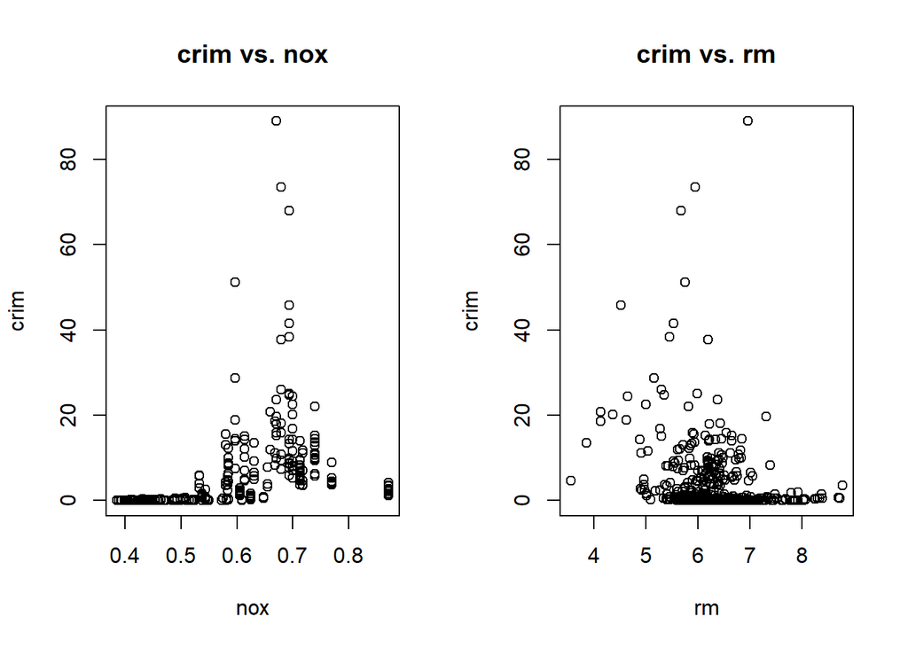

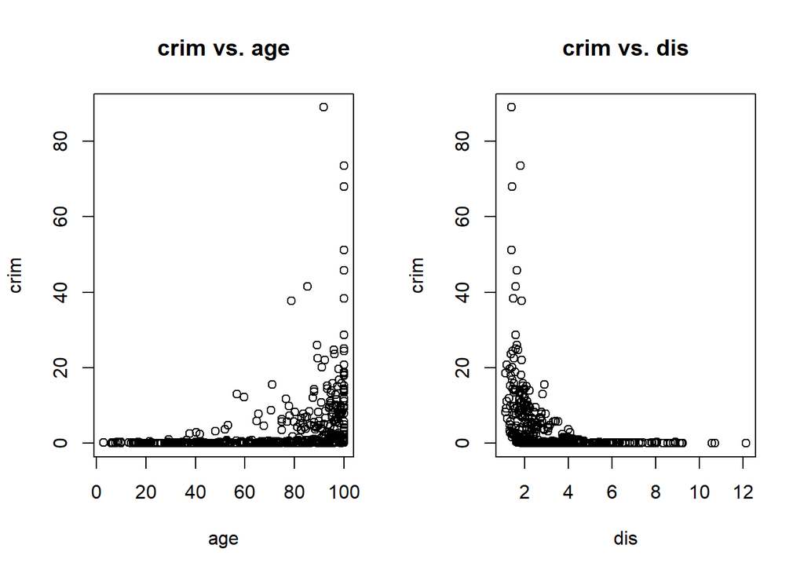

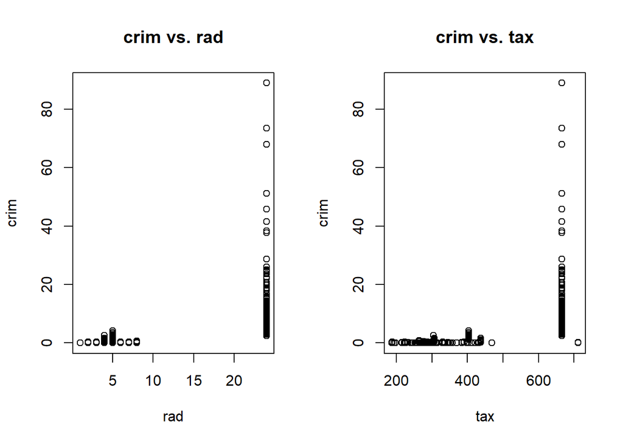

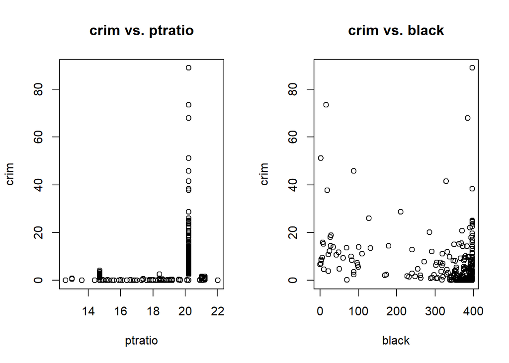

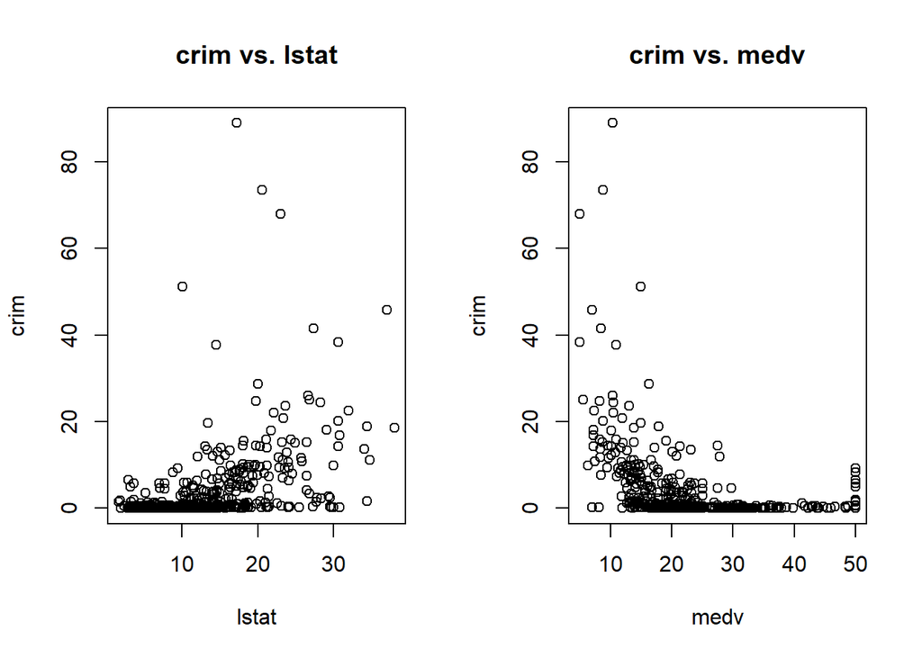

```r
par(mfrow=c(1,2))
for (i in 1:14){
  plot(Boston[,i], Boston$crim, xlab=names(Boston)[i], ylab="crim", main=paste("crim vs.", names(Boston)[i]))
}
```

Crime is positively correlated with **nox**, **age**, **rad**, **tax**, **lstat**, and negatively correlated with **medv**.

4. Do any of the suburbs of Boston appear to have particularly high crime rates? Tax rates? Pupil-teacher ratios? Comment on the range of each predictor.

The range of these particular predictors are reported below.

```r
summary(Boston$crim)
```

```
##     Min.  1st Qu.   Median     Mean  3rd Qu.     Max.
##  0.00632  0.08204  0.25651  3.61352  3.67708 88.97620
```

```r
summary(Boston$tax)
```

```
##    Min. 1st Qu.  Median    Mean 3rd Qu.    Max.
##   187.0   279.0   330.0   408.2   666.0   711.0
```

```r
summary(Boston$ptratio)
```

```
##    Min. 1st Qu.  Median    Mean 3rd Qu.    Max.
##   12.60   17.40   19.05   18.46   20.20   22.00
```

We’ll also take a look at histograms of these quantities.

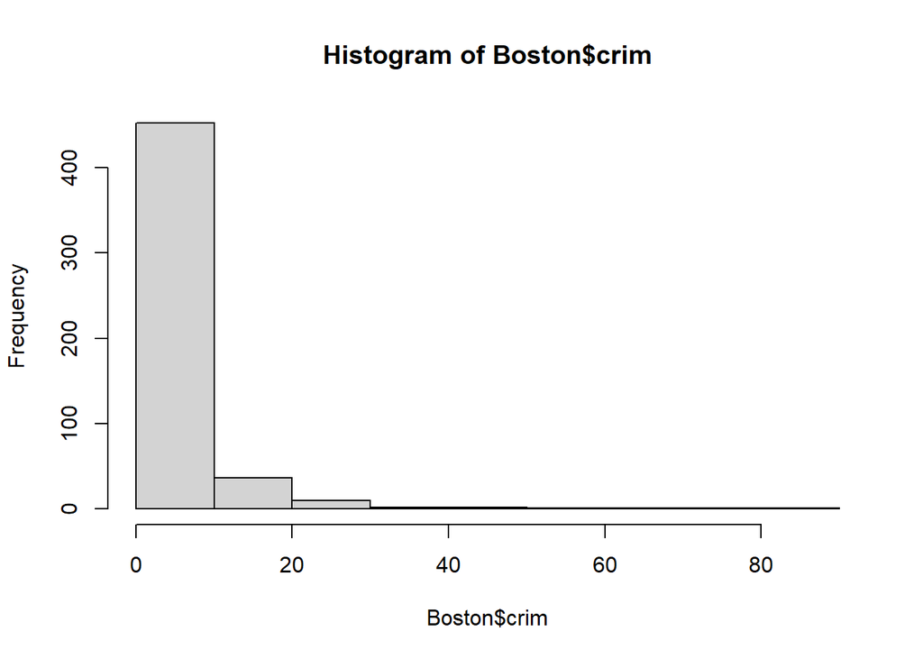

```r
hist(Boston$crim, main="Histogram of Boston$crim")
```

Most suburbs of Boston have a low crime rates (75% with less than 3.677 crimes per capita). But the upper tail is quite long, with one town even reaching a crime rate of 89%.

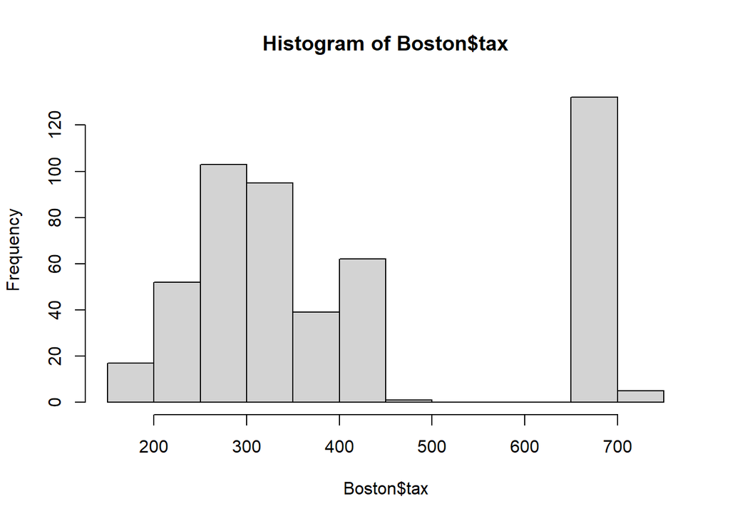

```r
hist(Boston$tax, main="Histogram of Boston$tax")
```

The **tax** distribution is bimodal, which may indicate that most neighborhoods were affordable, with a large handful being much more expensive.

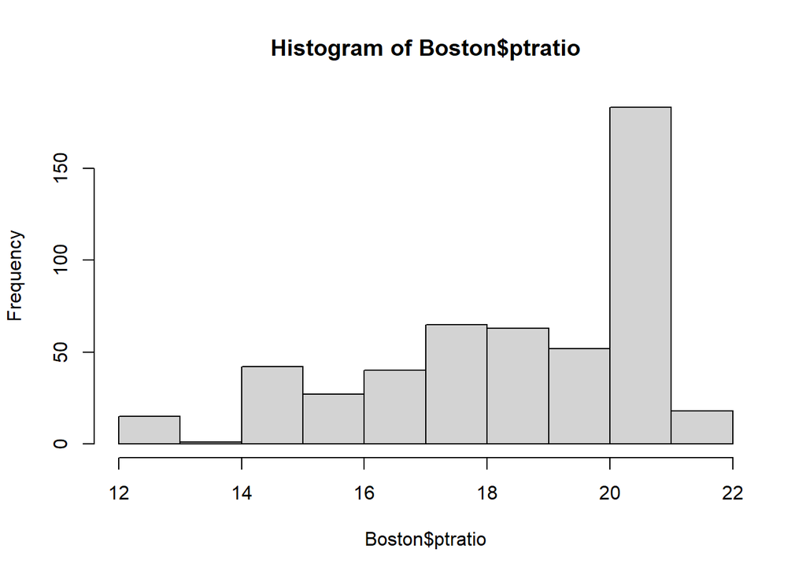

```r
hist(Boston$ptratio, main="Histogram of Boston$ptratio")
```

The **ptratio** distribution is left skewed, which means that there are many suburbs of Boston where each teacher has to tend to many students. Referring back to the scatterplot of **crim** vs. **ptratio** produced in part c, note that the neighborhoods with the highest crime rates have **ptratio** values near the 3rd quartile. Interestingly, neighborhoods with **ptratio** values between the 3rd and 4th quartiles have lower crime rates than those near the 3rd quartile.

Inspecting for potential confounders leads to some interesting observations.

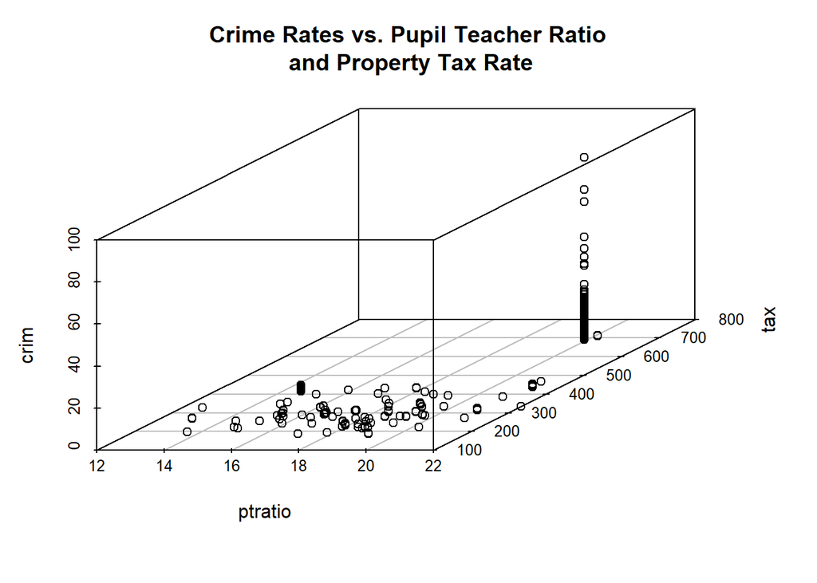

```r
scatterplot3d(x=Boston$ptratio, y=Boston$tax, z=Boston$crim, xlab="ptratio", ylab="tax", zlab="crim", main="Crime Rates vs. Pupil Teacher Ratio\n and Property Tax Rate")
```

Notice that the suburbs with the highest crime rates have ptratios at the 3rd quartile and very high tax rates.

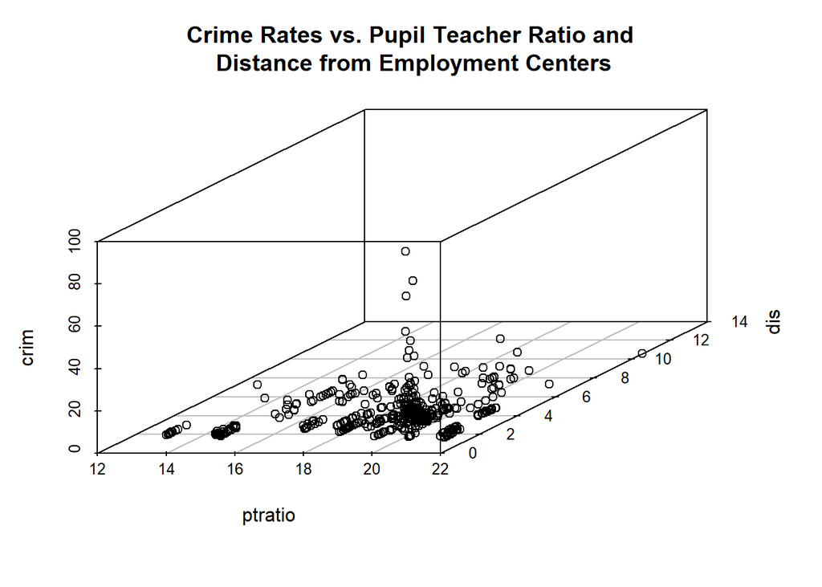

```r
scatterplot3d(x=Boston$ptratio, y=Boston$dis, z=Boston$crim, xlab="ptratio", ylab="dis", zlab="crim", main="Crime Rates vs. Pupil Teacher Ratio and\n Distance from Employment Centers")
```

All of the suburbs with the highest crime rates are very near to the city.

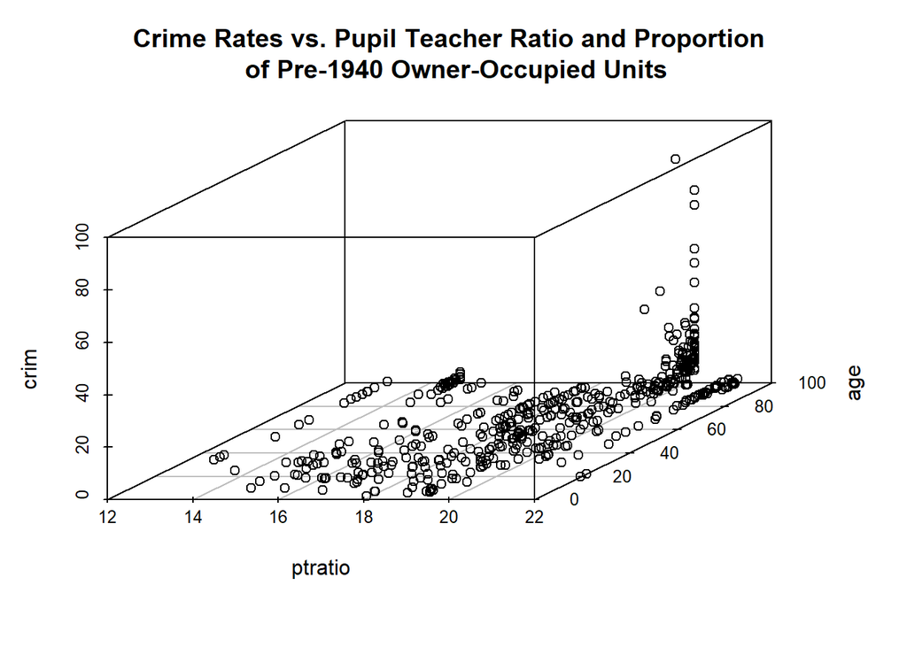

```r
scatterplot3d(x=Boston$ptratio, y=Boston$age, z=Boston$crim, xlab="ptratio", ylab="age", zlab="crim", main="Crime Rates vs. Pupil Teacher Ratio and Proportion \n of Pre-1940 Owner-Occupied Units")
```

All of the highest crime rate towns are very old.

From this, we observe that the towns with the highest crime rates have many old buildings and are very close to Boston-proper.

5. How many of the suburbs in this data set bound the Charles river?

```r
count = sum(Boston$chas)
percent = sum(Boston$chas)/length(Boston$chas) * 100
print( paste(toString(count),"suburbs border the Charles River, accounting for ",toString(percent),"% of all suburbs in this data set.")   )
```

```
## [1] "35 suburbs border the Charles River, accounting for  6.91699604743083 % of all suburbs in this data set."
```

6. What is the median pupil-teacher ratio among the towns in this data set?

```r
median(Boston$ptratio)
```

```
## [1] 19.05
```

7. Which suburb of Boston has the lowest median value of owner-occupied homes? What are the values of the other predictors for that suburb, and how do those values compare to the overall ranged for those predictors? Comment on your findings.

```r
min_val = min(Boston$medv)
min_val_town = Boston[ Boston$medv == 5 ,]
min_val_town
```

```
##        crim zn indus chas   nox    rm age    dis rad tax ptratio  black lstat
## 399 38.3518  0  18.1    0 0.693 5.453 100 1.4896  24 666    20.2 396.90 30.59
## 406 67.9208  0  18.1    0 0.693 5.683 100 1.4254  24 666    20.2 384.97 22.98
##     medv
## 399    5
## 406    5
```

There are two suburbs with the lowest median value of owner-occupied homes, 399 and 406. We show how the value of their predictors compares with the others by giving their percentiles below.

```r
percentile = ecdf(Boston$crim)
min_val_town_percentiles = data.frame(percentile(min_val_town$crim))
for (i in 2:14){
  percentile = ecdf(Boston[,i])
  min_val_town_percentiles = data.frame(min_val_town_percentiles, percentile(min_val_town[,i]))
}
names(min_val_town_percentiles) = names(Boston)
row.names(min_val_town_percentiles) = c(399, 406)
min_val_town_percentiles
```

```
##          crim        zn     indus    chas       nox        rm age        dis
## 399 0.9881423 0.7351779 0.8873518 0.93083 0.8577075 0.0770751   1 0.05731225
## 406 0.9960474 0.7351779 0.8873518 0.93083 0.8577075 0.1363636   1 0.04150198
##     rad       tax   ptratio     black     lstat        medv
## 399   1 0.9901186 0.8893281 1.0000000 0.9782609 0.003952569
## 406   1 0.9901186 0.8893281 0.3498024 0.8992095 0.003952569
```

The values of these suburbs’ predictors are very similar, except for the percentiles of **rm**, **dis**, **black**, and **lstat**.

8. In this data set, how many of the suburbs average more than seven rooms per dwelling? More than eight rooms per dwelling? Comment.

```r
# This is the percentage of suburbs averaging more than seven rooms per dwelling
sum(Boston$rm > 7) / length(Boston$rm > 7) * 100
```

```
## [1] 12.64822
```

```r
# This is the percentage of suburbs averaging more than eight rooms per dwelling
sum(Boston$rm > 8) / length(Boston$rm > 8)
```

```
## [1] 0.0256917
```

Now, to see how these values compare to the sample as a whole, we take the mean of each predictor over this subset, and then obtain the quantile of those means in the whole sample.

```r
# STEP 1: Calculate the mean of each predictor over this subset
rooms8 = Boston[Boston$rm > 8,]
rooms8
```

```
##        crim zn indus chas    nox    rm  age    dis rad tax ptratio  black lstat
## 98  0.12083  0  2.89    0 0.4450 8.069 76.0 3.4952   2 276    18.0 396.90  4.21
## 164 1.51902  0 19.58    1 0.6050 8.375 93.9 2.1620   5 403    14.7 388.45  3.32
## 205 0.02009 95  2.68    0 0.4161 8.034 31.9 5.1180   4 224    14.7 390.55  2.88
## 225 0.31533  0  6.20    0 0.5040 8.266 78.3 2.8944   8 307    17.4 385.05  4.14
## 226 0.52693  0  6.20    0 0.5040 8.725 83.0 2.8944   8 307    17.4 382.00  4.63
## 227 0.38214  0  6.20    0 0.5040 8.040 86.5 3.2157   8 307    17.4 387.38  3.13
## 233 0.57529  0  6.20    0 0.5070 8.337 73.3 3.8384   8 307    17.4 385.91  2.47
## 234 0.33147  0  6.20    0 0.5070 8.247 70.4 3.6519   8 307    17.4 378.95  3.95
## 254 0.36894 22  5.86    0 0.4310 8.259  8.4 8.9067   7 330    19.1 396.90  3.54
## 258 0.61154 20  3.97    0 0.6470 8.704 86.9 1.8010   5 264    13.0 389.70  5.12
## 263 0.52014 20  3.97    0 0.6470 8.398 91.5 2.2885   5 264    13.0 386.86  5.91
## 268 0.57834 20  3.97    0 0.5750 8.297 67.0 2.4216   5 264    13.0 384.54  7.44
## 365 3.47428  0 18.10    1 0.7180 8.780 82.9 1.9047  24 666    20.2 354.55  5.29
##     medv
## 98  38.7
## 164 50.0
## 205 50.0
## 225 44.8
## 226 50.0
## 227 37.6
## 233 41.7
## 234 48.3
## 254 42.8
## 258 50.0
## 263 48.8
## 268 50.0
## 365 21.9
```

```r
df = data.frame(mean(rooms8[,1]))
for (i in 2:14){
  df = data.frame(df, mean(rooms8[,i]))
}
names(df) = names(Boston)
df[2,] = rep(0,14)
append(df, c(0,0,0,0,0,0,0,0,0,0,0,0,0,0));
```

[output not shown]

[output cut: 28 more lines]

[output not shown]

```r
row.names(df) = c("mean", "quantile")

# STEP 2: Calculate the percentile of each mean within the distribution of the corresponding predictor in the whole sample
for (i in 1:14){
  quantile = ecdf(Boston[,i])
  df[2,i] = quantile(df[1,i])
}
df
```

```
##               crim         zn     indus      chas       nox        rm
## mean     0.7187954 13.6153846 7.0784615 0.1538462 0.5392385 8.3485385
## quantile 0.6264822  0.7549407 0.3992095 0.9308300 0.5375494 0.9901186
##                 age       dis       rad         tax    ptratio       black
## mean     71.5384615 3.4301923 7.4615385 325.0769231 16.3615385 385.2107692
## quantile  0.4486166 0.5395257 0.6916996   0.4743083  0.1778656   0.3557312
##               lstat       medv
## mean     4.31000000 44.2000000
## quantile 0.07509881  0.9545455
```